# Lab 06-Identifying Cohesive Subgroups

#### *What are the features of the network that “jump-out” when you examine the plot?*

Note that we are now working with a directed graph. To examine the *coreness* of the graph, we need to make a decision about how to treat the edges.

If we relax the constrain that all edges must be reciprocated, we can identify four kinds of dyads of increasingly strict connectivity:

- *Weakly n-connected*: *i* and *j* are joined by a semipath of length < *n*.
- *Unilaterally n-connected*: a path of length < *n* from *i* to *j* or from *j* to *i*.
- *Strongly n-connected*: *i* and *j* are connected by two reciprocal paths of length < *n*, where the paths may have different intermediary nodes.
- *Recursively n-connected*: *i* and *j* use same intermediary nodes and lines in reverse order as the path from *j* to *i*.

*The result is that we have 4 types of n-cliques: weakly, unilaterally, strongly, and recursively. We can see this in the `symmetrize()` function in the `sna` package.

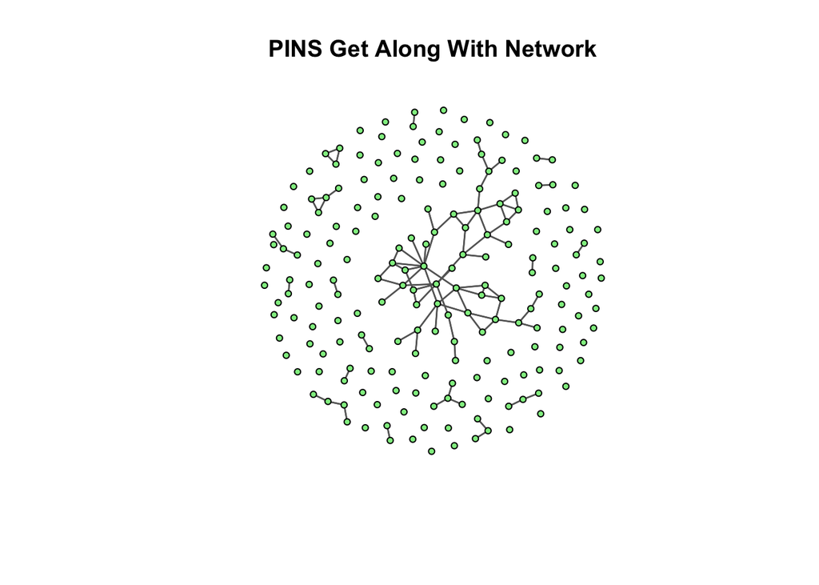

```r
?symmetrize

# Let's create a symmetrized get along network following the "strong" definition.
GA.net.strong <- symmetrize(GA.net,rule="strong")

# Now, take a look at the plot.
gplot(GA.net.strong, edge.col="grey40", vertex.col="lightgreen", main="PINS Get Along With Network",gmode="graph")
```

```r
# Now, let's look at the kcores.
GA.net.strong.kcores <- kcores(GA.net.strong,mode="graph")
table(GA.net.strong.kcores)
```

```
## GA.net.strong.kcores
##   0   1   2
## 102  61  33
```

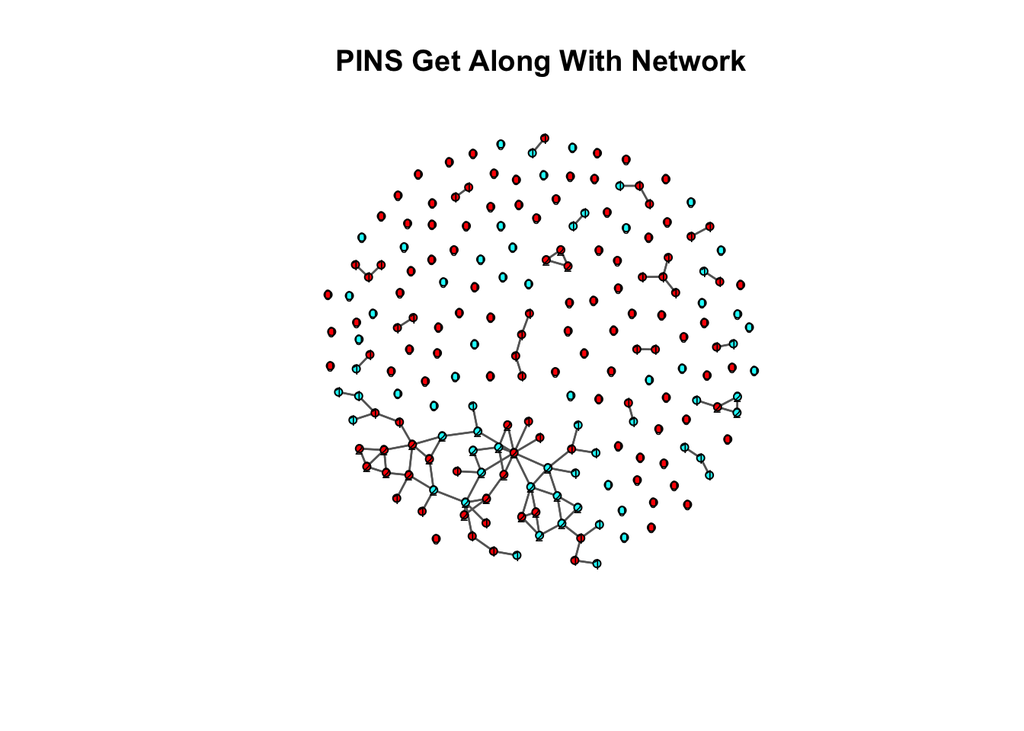

```r
# Let's look at a plot.
v.cols <- rainbow(max(GA.net.strong.kcores))
v.cols <- v.cols[GA.net.strong.kcores]
gplot(GA.net.strong, edge.col="grey40", vertex.col=v.cols, main="PINS Get Along With Network",gmode="graph", label = GA.net.strong.kcores, label.pos = 5, label.cex = 0.6)
```

#### *What if we use the **weak** rule?*

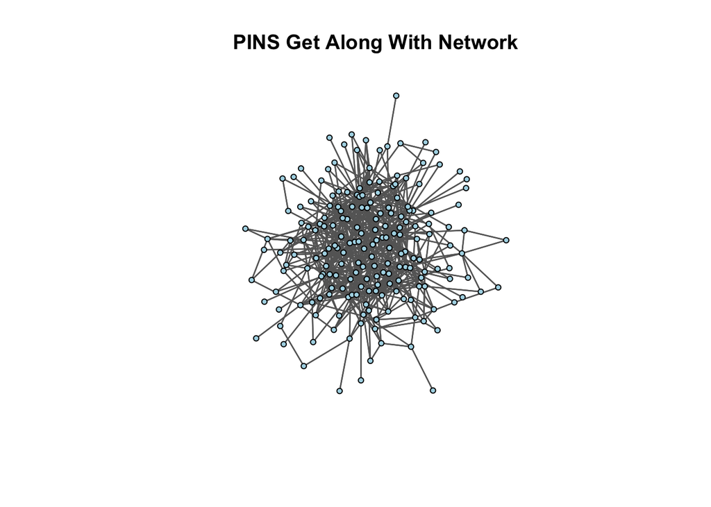

```r
GA.net.weak <- symmetrize(GA.net,rule="weak")
gplot(GA.net.weak, edge.col="grey40", vertex.col="lightblue", main="PINS Get Along With Network",gmode="graph")
```

```r
GA.net.weak.kcores <- kcores(GA.net.weak,mode="graph")
table(GA.net.weak.kcores)
```

```
## GA.net.weak.kcores
##  1  2  3  4  5  6
## 18 32 17 37 66 26
```

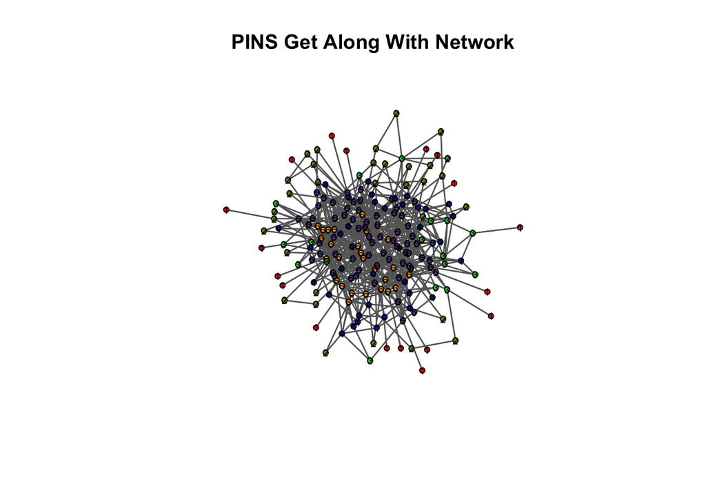

```r
# Let's look at a plot.
library(RColorBrewer)
rbPal <- colorRampPalette(c("red","green","blue","orange"))
v.cols <- rbPal(6)[as.numeric(cut(GA.net.weak.kcores,breaks = 6))]
gplot(GA.net.weak, edge.col="grey40", vertex.col=v.cols, main="PINS Get Along With Network",gmode="graph", label = GA.net.weak.kcores, label.pos = 5, label.cex = 0.6)
```

#### *Questions?*

##### *Please* report any needed corrections to the [Issues](https://github.com/jacobtnyoung/SAND/issues/new) page. Thanks!

###### *Last updated 06 January, 2023*